# Index

ZACHARY_ARENSON

11/11/2019

# Report on U.S.Shootings

## Summary Info

[Original Data Source](https://www.gunviolencearchive.org/reports/mass-shooting)

In 2018, 340 shooting events were reported to have occured in the United States. From that number of shootings events, 373 people died during the shooting attacks. Meaning for every one attacker, a person died from the horrible consquences of society being unable to respond quick enough to a domestic attack. Out of the entire country, the state of California suffered the most injuries and deaths from a mass shooting event. More shootings occured depending on the state and, even cities such as Chicago, 135 noted within the represented data. Concluding that certain areas struggle with mass shooting events on a larger level than other locations within the U.S.

## Summary Table

| state | sum |
| --- | --- |
| California | 50 |
| Florida | 48 |
| Pennsylvania | 35 |
| Texas | 29 |
| Illinois | 21 |
| Tennessee | 19 |
| Louisiana | 15 |
| North Carolina | 14 |
| Maryland | 13 |
| Ohio | 13 |
| Alabama | 12 |
| Missouri | 12 |
| Indiana | 10 |
| Michigan | 10 |
| Colorado | 9 |
| Arkansas | 7 |
| Kentucky | 7 |
| Delaware | 5 |
| New Mexico | 5 |
| New York | 5 |
| South Carolina | 5 |
| Arizona | 4 |
| New Jersey | 4 |
| Washington | 4 |
| Georgia | 3 |
| Nevada | 3 |
| District of Columbia | 2 |
| Oklahoma | 2 |
| Virginia | 2 |
| Kansas | 1 |
| Minnesota | 1 |
| Mississippi | 1 |
| Nebraska | 1 |
| Wisconsin | 1 |
| Connecticut | 0 |
| Massachusetts | 0 |
| Utah | 0 |

### Important Insights from Table

A trend of higher deaths is associated with southern states in the U.S. This could mean culture or gun law issues associated with the states cause of higher death proportions. However, location could be less important, rather law and gun control methods could be the larger issue due to Maryland being a higher death proportion state. However, regardless of either statement being true, there is definently a trend associated between these states and a factor within their state level societies.

## Description of a particular incident

An interesting point of observation, is that Chicago, 135 had the most dates recorded of impact, regarding deaths and injury. However, the highest injured count was 8 with 0 deaths on August 5, 2018. The shooting took place in Illinois, Chicago, 1300 block of W 76th St. Meaning, the amount of shootings that lead to Chicago, 135 being the most impacted are built over numerous shootings rather than other impacted cities with large injured and killed during shooting events.

[News Report Referring to Specific Shooting Mentioned](https://www.chicagotribune.com/news/breaking/ct-met-chicago-shootings-violence-20180804-story.html)

## Interactive map

[interactive chart not shown]

### Two insights from the map

1. Florida seems to have a larger shooting impact compared to other states with fewer shootings.
2. The east coast states are more frequently impacted by mass shootings based on the visual implications.

## Bar Plot Graph

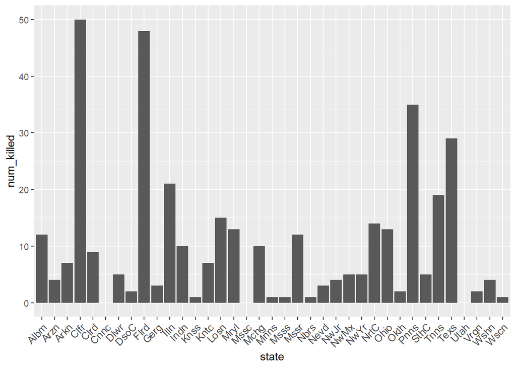

### Two Insights

I chose the specific bar chart because of my interest in visually comparing the number of people killed by state. An insight I gained from the chart is that the states of California and Florida are significantly more impacted by mass shootings. Another insight is that while Pennsylvania and Texas are impacted significantly more than other states, the average is much lower than the higher impacted states.

## Critical reflection

A specific finding from my report argues an implication between cities known for higher levels of poverty and crime and mass shootings. Predictive programs, such as PredPol referenced in the book, help analysists understand trends in mass shooting impacts across the U.S. However, these data sets are available to the public, meaning criminals can do research on safer places for them to conduct criminal activities. Also meaning that poorer areas and its communities are treated and generalized as criminals and or potential ones.